# 36-315 Homework 12, Spring 2017

Due Wednesday, May 3rd, 2017 (12pm ET) on Blackboard

## Homework 12: Text and Time

*General instructions for all assignments*:

# Easy Problems

## Problem 0

(4 points)

**Organization, Themes, and HTML Output**

1. For all problems in this assignment, organize your output as follows:
- Use code folding for all code. See [here](http://blog.rstudio.org/2016/03/21/rmarkdown-v0-9-5/) for how to do this.
- Use a floating table of contents.
- Suppress all warning messages in your output by using `warning = FALSE` and `message = FALSE` in every code block.
- Use tabs only if you see it fit to do so – this is your choice.
2. For all problems in this assignment, adhere to the following guidelines for your `ggplot` theme and use of color:
- Do not use the default `ggplot()` color scheme.
- For any bar chart or histogram, outline the bars (e.g. with `color = "black"`).
- Do not use both red and green in the same plot, since a large proportion of the population is red-green colorblind.
- Try to only use three colors (at most) in your themes. In previous assignments, many students are using different colors for the axes, axis ticks, axis labels, graph titles, grid lines, background, etc. This is unnecessary and only serves to make your graphs more difficult to read. Use a more concise color scheme.
- Make sure you use a white or gray background (preferably light gray if you use gray).
- Make sure that titles, labels, and axes are in dark colors, so that they contrast well with the light colored background.
- Only use color when necessary and when it enhances your graph. For example, if you have a univariate bar chart, there’s no need to color the bars different colors, since this is redundant.
- In general, try to keep your themes (and written answers) professional. Remember, you should treat these assignments as professional reports.
3. Treat your submission as a formal report:
- Use complete sentences when answering questions.
- Answer in the context of the problem.
- Treat your submission more as a formal “report”, where you are providing details analyses to answer the research questions asked in the problems.
4. What style guide are you using for this assignment?

## Problem 1

(5 points)

**World War II Data Visualization Video**

Watch the interactive version of [this video](http://www.fallen.io/ww2/). What do you like about it from a data visualization perspective (1-3 sentences)? What do you dislike, if anything (1-3 sentences)?

## Problem 2

(4 points each; 16 points total)

**Time Series and Dates in `ggplot()`**

Note: Almost all code for this problem is given to you already. Please take time to understand what the code does! You will be asked to do similar problems on your own in the next homework assignment.

1. Load the new “big bike” dataset from the course GitHub page. This is similar to the NYC Citi Bike dataset from earlier in the semester, except with data going back to 2013. Create a new variable, `start_date`, with the following code:

```r
library(tidyverse)
big_bike <- read_csv("https://raw.githubusercontent.com/sventura/315-code-and-datasets/master/data/big_bike.csv")

#  Add start_date variable to big_bike, and a bunch of other variables
big_bike <- mutate(big_bike,
                   start_date = as.Date(start_date),
                   birth_decade = paste0(substr(`birth year`, 1, 3), "0s"),
                   hour_of_day = as.integer(substr(time_of_day, 1, 2)),
                   am_or_pm = ifelse(hour_of_day < 12, "AM", "PM"),
                   day_of_week = weekdays(start_date),
                   less_than_30_mins = ifelse(tripduration < 1800,
                                              "Short Trip", "Long Trip"),
                   weekend = ifelse(day_of_week %in% c("Saturday", "Sunday"),
                                    "Weekend", "Weekday"))
```

- How many rows and columns are in the result?
- What are the minimum and maximum bike trip dates?
2. Let’s plot the number of trips over time. First, we need to calculate the number of trips on any given day. This is easy with the `dplyr` package. Using the code below, we now have a new data frame (called `trips_per_day`). We can use it to create a nice time series plot with `ggplot()`, `geom_line()`, and `scale_x_date()` to properly format the x-axis:

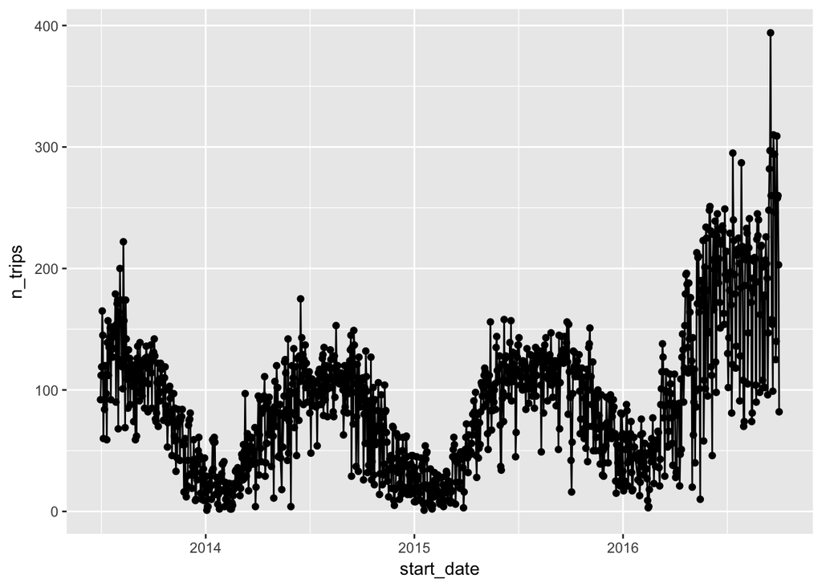

```r
library(ggplot2)

#  Summarize the big_bike, creating a new data.frame that includes the number
#  of trips taken on each day
trips_per_day <- big_bike %>%
  group_by(start_date) %>%
  summarize(n_trips = n())

#  Create a time series plot with the dates on the x-axis and the number of
#  trips per day on the y-axis
ggplot(trips_per_day, aes(x = start_date, y = n_trips)) + geom_line() +
  scale_x_date() + geom_point()
```

Add an appropriate title and axis labels to the graph above. Be sure to adjust the `fig.height` and `fig.width` to make the graph more easily readable.

3. Answer the following questions:
- Try removing `geom_point()` from the code in (b). What happens?
- Do you notice any trends in the number of bike rides over time? Use the principles we covered in class to discuss the time series.
- Which date had the most bike trips?
4. Repeat part (b), but this time, split the time series into subscribers and customers in the `usertype` variable, and color by the `usertype` variable. (Hint: All you have to do is map an aesthetic of the graph to the `usertype` variable.)

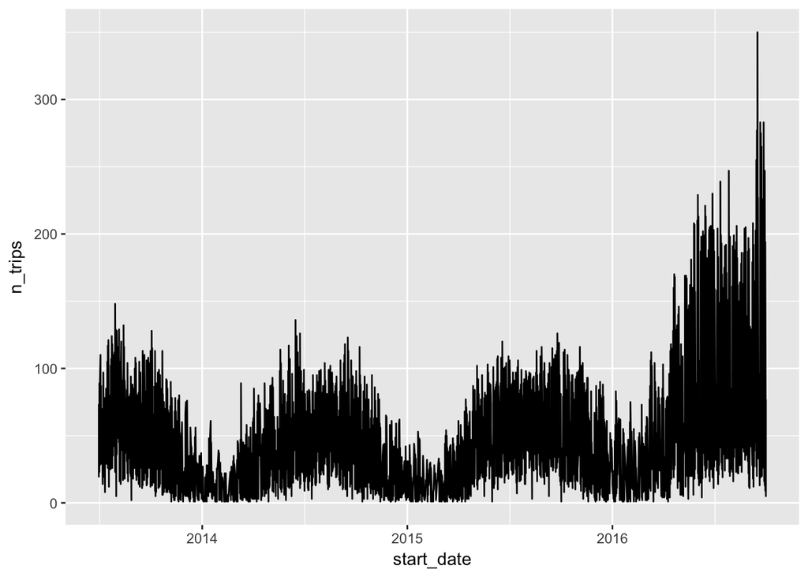

```r
#  Summarize the big_bike, creating a new data.frame that includes the number
#  of trips taken on each day, split by usertype
trips_per_day_usertype <- big_bike %>%
  group_by(start_date, usertype) %>%
  summarize(n_trips = n())

#  Create a time series plot with the dates on the x-axis and the number of
#  trips per day on the y-axis, split by usertype
ggplot(trips_per_day_usertype, aes(x = start_date, y = n_trips)) +
  geom_line() + scale_x_date()
```

- Add appropriate titles, labels, and legend labels to your graph.
- Use a non-default color scheme in the plot
- Which time series appears to have more fluctuation / variability?

## Problem 3

(2 points each; 10 points total)

**Understanding Autocorrelations and Autocorrelation Plots**

1. Autocorrelations are just the correlation of a time series with itself at different lags. Let’s start by looking at a totally random, made up time series: `rand_ts <- rnorm(1000)`. This is just a bunch of random numbers from a Normal(0, 1) distribution. Use `acf(rand_ts, plot = FALSE)` to look at the correlation of the “time series” and itself at different lags. Since this “time series” is just 1000 random draws from a Normal(0, 1) distribution, most of the autocorrelations should be near zero.
- Is this true?
- Which autocorrelation is NOT near zero?
- Does this make sense? Why or why not?
2. Autocorrelation plots show the correlation between the time series and itself at all of the different possible lags. The (auto)correlations are plotted on the y-axis, and the lags are shown on the x-axis. Create an autocorrelation plot of the random time series from (a). To do this, just type `acf(rand_ts, plot = TRUE)`. In the resulting plot, the blue dotted lines indicate statistical significance. Any correlation above the positive blue line or below the negative blue line is significantly different from zero.
- Are any of the autocorrelations significantly different from zero in your plot?
- Does this make sense? Why or why not?
3. Calculate the autocorrelations of the NYC Bike Data daily-rides time series we created in Problem 1 (`trips_per_day$n_trips`). To do this, use (e.g.) `acf(trips_per_day$n_trips, plot = FALSE)`. Store these in an object called `bike_acf`. Type `names(bike_acf)`.
- What information is included in the autocorrelation results?
- Type `bike_acf$acf` and `bike_acf$lag`. What information is stored in the `acf` and `lag` pieces?
4. Create two autocorrelation plots of the `trips_per_day_usertype` time series: One for subscribers, and one for customers. Arrange these base-R graphics into a 1x2 grid. Specify the `main` argument to give your graph an informative title. The code to do this is partially complete for you below:

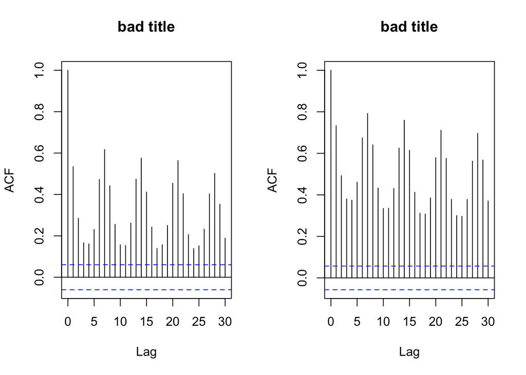

```r
par(mfrow = c(1, 2))
acf(filter(trips_per_day_usertype, usertype == "Customer")$n_trips, main = "bad title")
acf(filter(trips_per_day_usertype, usertype == "Subscriber")$n_trips, main = "bad title")
```

- Which time series typically has higher autocorrelations?
5. Describe the autocorrelation plot from (d).
- Which lags have the highest significant, positive autocorrelations?
- What does it mean, in the context of the problem, to have a significant positive autocorrelation? In the context of the problem (NYC Citi Bike Data), why do you see this pattern of autocorrelations in the plot?

### Note

- Later in the homework, you will be asked to create a `ggplot()` version of autocorrelation plots.
- In the BonusProblems file, you will be asked to create a new `ggplot()` geometry for autocorrelation plots.

# Hard Problems

## Problem 4

(14 points)

**Word Clouds and Tidy Text Mining**

1. (2 points) Read Sections 2, 2.1, and 2.5 of the Tidy Text Mining book from the Lecture 22 R Demo. What does the `unnest_tokens()` function do?
2. (4 points) Load the Airline Tweets dataset from one of the first assignments. What column contains the text of the tweets? Run the following code and give an interpretation of the resulting word cloud (you may need to install the `tidytext` and `wordcloud` packages first):

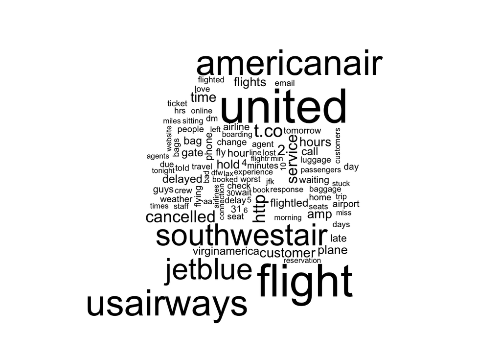

```r
#install.packages("tidytext")
#install.packages("wordcloud")
library(tidyverse)
library(tidytext)
library(wordcloud)
data(stop_words)

airline_tweets <- read_csv("https://raw.githubusercontent.com/sventura/315-code-and-datasets/master/data/Tweets.csv")

my_tweets <- dplyr::select(airline_tweets, tweet_id, text) %>%
  unnest_tokens(word, text) %>%
  anti_join(stop_words) %>%
  count(word) %>%
  with(wordcloud(word, n, max.words = 100))
```

3. (8 points) Create a separate wordcloud for each airline. Arrange the results into a 2x3 grid. Interpret the results: Are there any words that are more/less common for certain airlines?

## Problem 5

(4 points each; 32 points total)

**Moving Average Plots**

In Problem 2, we created a time series plot of the NYC bike dataset (“Big Bike”), visualizing the number of trips per day as a function of time. Here, we’re going to add a moving average line to the plot.

1. Moving averages are calculated as follows: Given a “window width” `ww`, the moving average at time point `tt` in the time series is: `mean(my_time_series[(tt-ww+1):tt])`. Write a function, called `moving_average` that calculates the moving average of a time series vector at a single time point. The function should take three inputs: the time series, the window width, and the time point at which you want the moving average. The code is started for you below.

```r
#  time_series:  A vector containing the time series values
#  ww:  The window width for the moving average
#  tt:  The point at which we want the moving average (leading up to that point)
moving_average <- function(tt, time_series, ww) {
  #  Throw an error if the window width is too big
  if (ww > length(time_series))
    stop("Window width is greater than length of time series")

  #  If the window width is greater than the time point, return NA
  if (tt < ww)  return(NA)

  #  Your code here!
}
```

2. Write a second function, called `get_moving_averages`, that calculates *all* moving averages for a given time series vector. Your function should take two inputs: the time series and the window width. This function should call your function from part (a). The code is started for you below.

```r
#  time_series:  A vector containing the time series values
#  ww:  The window width for the moving average
get_moving_averages <- function(time_series, ww) {
  #  Throw an error if the window width is too big
  if (ww > length(time_series))
    stop("Window width is greater than length of time series")

  #  Your code here!
}
```

```r
#  time_series:  A vector containing the time series values
#  ww:  The window width for the moving average
#  tt:  The point at which
#  weights:  the weights to be used in the moving average
#  Note:  length(weights) should always equal ww!
weighted_moving_average <- function(tt, time_series, ww, weights = NULL) {
  #  Throw an error if the window width is too big
  if (ww > length(time_series))
    stop("Window width is greater than length of time series")

  #  If weights are not specified, use standard weights
  if (is.null(weights))  weights <- rep(1/ww, ww)

  #  Throw an error if the window width is too big
  if (length(weights) != ww)
    stop("Weights should have the same length as the window width")

  #  If the window width is greater than the time point, return NA
  if (tt < ww)  return(NA)

  #  Standardize the weights so they sum to 1
  weights <- weights / sum(weights)

  #  Your code here!
}


#  time_series:  A vector containing the time series values
#  ww:  The window width for the moving average
#  weights:  the weights to be used in the moving average
#  Note:  length(weights) should always equal ww!
get_weighted_moving_averages <- function(time_series, ww, weights) {
  #  Throw an error if the window width is too big
  if(ww > length(time_series))  stop("Window width is greater than length of time series")

  #  If weights are not specified, use standard weights
  if (is.null(weights))  weights <- rep(1/ww, ww)

  #  Throw an error if the window width is too big
  if (length(weights) != ww)
    stop("Weights should have the same length as the window width")

  #  Standardize the weights so they sum to 1
  weights <- weights / sum(weights)

  #  Your code here!
}
```

## Problem 6

(20 points)

**Create `ggplot()` ACF Plots**

Earlier in this assignment, we learned about the `acf()` function and autocorrelation plots. `acf()` uses base-R graphics. Your task in this problem is to create a `ggplot()` version of autocorrelation plots. Specifically, you should:

- Write a function that takes a time series as input (e.g. the `n_trips` column of `trips_per_day`, or the `rand_ts` from HW12).
- The function should compute the autocorrelations for the time series, and store them in a new data frame with one column indicating the lag, and another columns indicating the autocorrelation at that lag.
- Use `geom_line()`, `geom_segment()`, `geom_hline()`, and other `ggplot()` geometries to draw a graph that mimics the autocorrelation plots from `acf()`. That is, you should have vertical lines indicating the autocorrelation at each lag, and blue horizontal lines plotted at the values $0 +/- 1.96 / \sqrt(n)$, where $n$ is the number of rows in the dataset.
- The function should output a `ggplot()` object that has the default title and axis labels, so that these can be added to the object after calling the function.
- The result should render a graph that looks similar to what you get from `acf()`.
- You are allowed (and encouraged!) to use the `acf()` function to calculate the autocorrelations.

Demonstrate that your function works on the `rand_ts` object and the `trips_per_day` dataset. Compare your graphs to the base-R `acf()` graph.

# Bonus Problems

See the BonusProblems assignment on Blackboard.